# Homework

by 21030

2021-12-21

# The homework 1

## Questions

Give three simple examples including text,figures,and tables by using knitr.

## Texts

```r
#Some simple codes are written as follows:
x1<-c(1.2,2.6, 3.3,4.5,6.1,6.9,7.5,8.4,9.8,10.1,11.2,12.8,13.5,14.4,15.4,16.7)
x2<-c(0.98,0.87,0.85,0.80,0.74,0.69,0.65,0.60,0.52,0.49,0.44,0.39,0.28,0.19,0.15,0.08)
x3<-c(12.6,13.1,14,15.1,16.8,17.2,18.3,19.1,20.1,21.2,22.3,23.5,24.6,25.4,26.7,27.8)
y<-c(53,56,57,58.9,59.9,60.4,61.9,62.8,63.9, 65, 66.4,68.2,69.9,70.8,72.2,74)
fun1<-lm(y~I(x1^2)+x1+x2+x3)
fun1
```

```
##
## Call:
## lm(formula = y ~ I(x1^2) + x1 + x2 + x3)
##
## Coefficients:
## (Intercept)      I(x1^2)           x1           x2           x3
##   64.874799    -0.002834     0.803319   -11.113530    -0.101092
```

```r
summary(fun1)$coef
```

```
##                  Estimate  Std. Error    t value     Pr(>|t|)
## (Intercept)  64.874798657 7.921901086  8.1892967 5.226238e-06
## I(x1^2)      -0.002834001 0.009315406 -0.3042274 7.666326e-01
## x1            0.803318777 0.495033489  1.6227564 1.329264e-01
## x2          -11.113530242 5.921585642 -1.8767828 8.730953e-02
## x3           -0.101092012 0.476458879 -0.2121736 8.358519e-01
```

## table

```r
#Let's take a look at the data about the island by using a table.
knitr::kable(head(islands))
```

|  | x |
| --- | --- |
| Africa | 11506 |
| Antarctica | 5500 |
| Asia | 16988 |
| Australia | 2968 |
| Axel Heiberg | 16 |
| Baffin | 184 |

The head function means that only the first six data are taken. Let us see data about rock:

```r
knitr::kable(head(rock))
```

| area | peri | shape | perm |
| --- | --- | --- | --- |
| 4990 | 2791.90 | 0.0903296 | 6.3 |
| 7002 | 3892.60 | 0.1486220 | 6.3 |
| 7558 | 3930.66 | 0.1833120 | 6.3 |
| 7352 | 3869.32 | 0.1170630 | 6.3 |
| 7943 | 3948.54 | 0.1224170 | 17.1 |
| 7979 | 4010.15 | 0.1670450 | 17.1 |

## Figure

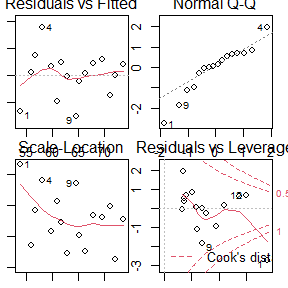

```r
#the graph of fun1 is shown as follows:
par(mar=c(1,1,1,1))
par(mfrow=c(2,2))
plot(fun1)
```

The `echo = FALSE` parameter are aimed at preventing printing of the R code . Another example:

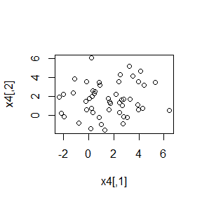

```r
 x4=matrix(rnorm(100,mean=1.5,sd=2),ncol=2)
 plot(x4)
```

# The homework 2

## Answer

#3.4 由运行结果知，对任意Sigma，模拟结果都接近实际图形

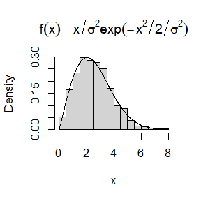

```
## [1] 2.041337
```

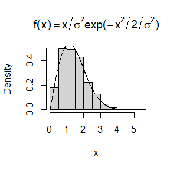

```
## [1] 1.136157
```

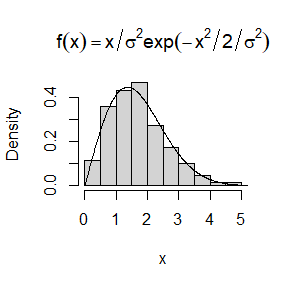

```
## [1] 1.361108
```

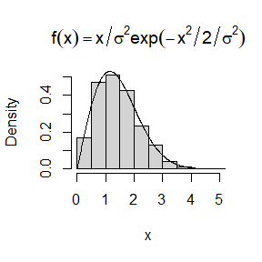

```
## [1] 1.146613
```

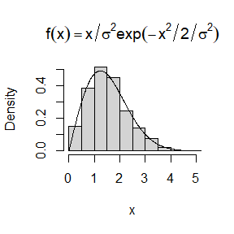

```
## [1] 1.231996
```

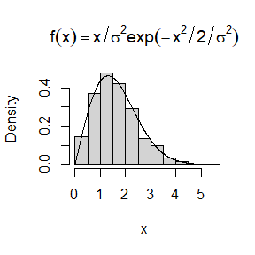

```
## [1] 1.311259
```

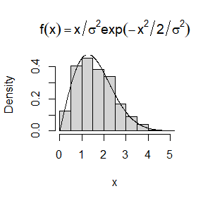

```
## [1] 1.277865
```

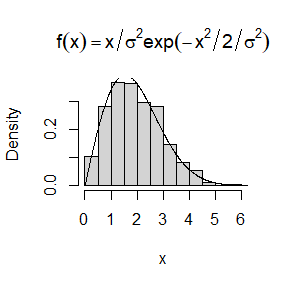

```
## [1] 1.541825
```

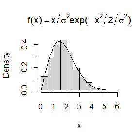

```
## [1] 1.42209
```

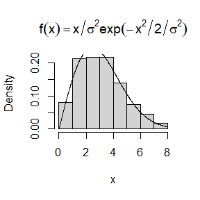

```
## [1] 2.466094
```

```r
#Develop an algorithm to generate random samples from a Rayleigh(σ) distribution
n <- 1000
a<-runif(10,0,3) #取随机数
for (i in seq_along(a)) {
  sigma <- a[[i]]
  u <- runif(n)
  x <- (-2*sigma^2*log(u))^(1/2) # F(x) = 1-exp(-x^2/2/sigma^2)  x>=0
  #作图
  hist(x, prob = TRUE, main = expression(f(x)==x/sigma^2*exp(-x^2/2/sigma^2)))
  y <- seq(0, 8, .01)
  lines(y, y/sigma^2*exp(-y^2/2/sigma^2))
  print(sigma)  #输出结果
}
```

#3.11 由运行结果知，当P接近0.5时，会出现双峰混合

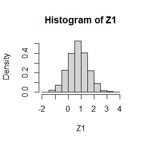

```r
# Generate a random sample of size 1000 from a normal location mixture
n <- 1000
X1 <- rnorm(n,0,1)
X2 <- rnorm(n,3,1)
Z1 <- 0.75*X1+0.25*X2
hist(Z1, prob = T)
```

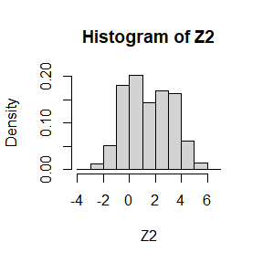

```r
p<-sample(c(0,1),n,replace = TRUE)
Z2 <- p*X1+(1-p)*X2
hist(Z2, prob = T)
```

```r
sum(p)/n
```

```
## [1] 0.511
```

```r
#Write a program to simulate a compound Poisson(λ)–Gamma process (Y has a Gamma distribution)
r<-2;beta<-4
X1<-c()
y1<-c()
t<-10;lambda<-5   #lambda为5;t为10时
for (j in 1:100) {
  N<-rpois(1,t*lambda)
  y<-rgamma(N,r,beta);
  X1[j]<-(sum(y))
  y1[j]<-(y[1])
}
X1   #模拟产生X1的100个值
```

```
##   [1] 26.67410 17.32801 28.87882 20.75048 21.02150 25.41500 28.39604 24.40717
##   [9] 28.02793 29.07062 23.93686 33.40526 30.58167 21.19005 25.14626 24.27024
##  [17] 25.36455 25.72653 24.70447 16.02644 28.39603 17.19915 23.38731 29.72835
##  [25] 24.63942 21.12837 31.91390 28.86499 32.89281 21.73821 17.52856 29.21229
##  [33] 22.86874 27.03130 26.98428 27.33783 34.17838 27.42824 25.82687 32.15779
##  [41] 27.97578 17.84105 26.08346 23.09739 31.02846 30.24370 21.86369 33.46469
##  [49] 29.43241 22.84214 23.01892 23.17636 24.50428 25.92024 27.49668 21.85568
##  [57] 27.38408 21.16584 23.51258 23.18518 26.09578 24.77365 21.59391 24.24442
##  [65] 21.97087 25.67438 26.18534 20.83576 26.31588 27.29302 20.97683 23.30603
##  [73] 22.99846 28.27886 26.00843 21.58223 22.80374 26.93436 27.89176 18.25509
##  [81] 20.85132 27.54561 24.62828 19.75306 24.36776 30.76245 20.72949 23.60383
##  [89] 19.50930 26.17442 30.01523 21.43645 23.82580 27.47842 33.77807 20.24386
##  [97] 18.86310 26.68739 23.38360 26.41897
```

```r
mean(X1)
```

```
## [1] 25.09933
```

```r
var(X1)
```

```
## [1] 16.14121
```

```r
EX<-t*lambda*mean(y1);EX  #理论期望
```

```
## [1] 26.14139
```

```r
VarX<-t*lambda*(var(y1)+(mean(y1))^2);VarX  #理论方差
```

```
## [1] 21.41435
```

```r
r<-2;beta<-4
X2<-c()
y1<-c()
t<-10;lambda<-10   #lambda为10;t为10时
for (j in 1:100) {
  N<-rpois(1,t*lambda)
  y<-rgamma(N,r,beta)
  X2[j]<-(sum(y))
  y1[j]<-(y[1])
}
X2   #模拟产生X2的100个值
```

```
##   [1] 52.82054 48.05147 65.52084 54.86528 53.18455 41.03843 60.82594 58.79974
##   [9] 44.47983 52.08856 48.63267 48.51692 40.04193 41.60813 53.19814 44.84764
##  [17] 53.90962 50.96066 54.91329 38.50112 41.80562 47.16225 53.14623 34.21168
##  [25] 45.98065 56.36872 44.93224 49.20663 59.06285 55.62287 64.94777 45.38282
##  [33] 47.01904 43.72395 55.53953 54.95962 48.05500 56.48289 59.55826 60.03982
##  [41] 48.66774 62.96436 50.53225 50.20416 55.25446 61.14440 40.55429 42.11207
##  [49] 41.64506 52.98825 45.59666 47.51688 44.14499 51.28934 47.93322 48.10946
##  [57] 63.36746 47.62825 41.14756 56.73383 48.34484 59.53611 42.01196 39.56891
##  [65] 56.81751 47.39413 45.13513 47.10483 40.81586 52.81195 42.01843 51.61649
##  [73] 61.63420 45.40379 55.59514 46.59014 47.01336 49.42919 62.80545 46.89609
##  [81] 53.55127 58.93116 51.42405 48.45301 56.50885 53.01067 37.11705 41.06886
##  [89] 57.63839 47.87117 51.32363 48.59809 46.79835 46.83117 52.03152 42.74097
##  [97] 45.25223 55.58059 49.14912 47.29585
```

```r
mean(X2)
```

```
## [1] 50.09268
```

```r
var(X2)
```

```
## [1] 45.6282
```

```r
EX<-t*lambda*mean(y1);EX  #理论期望
```

```
## [1] 44.25654
```

```r
VarX<-t*lambda*(var(y1)+(mean(y1))^2);VarX  #理论方差
```

```
## [1] 28.86159
```

```r
r<-2;beta<-2
X3<-c()
y1<-c()
t=10;lambda=10  #lambda为10;t为10时
for (j in 1:100) {
  N<-rpois(1,t*lambda)
  y<-rgamma(N,r,beta)
  X3[j]<-(sum(y))
  y1[j]<-(y[1])
}
X3   #模拟产生X3的100个值
```

```
##   [1] 107.55654  96.48313  70.55086  84.23565  99.91299 109.41352  91.17938
##   [8]  96.85838 100.95081 102.91325  99.34776  93.92400 118.86252 105.03476
##  [15]  96.97798  94.40719  97.80828  95.95839  92.28940  90.29750  88.65854
##  [22] 103.09956  97.36614 105.46950 101.20619 107.61007 107.66504 114.67668
##  [29] 112.73902  83.21100 129.43281 102.45142  95.02096 106.66362 110.08522
##  [36] 114.96626 106.29182  87.33114  80.93958 112.42657  80.73800 109.52493
##  [43] 112.73858  98.58419  82.33745  83.57221  95.21430 115.62821  80.97807
##  [50]  92.69271  84.91325  92.73571 105.42174  93.70439 120.38524 105.51305
##  [57]  99.49163 129.03164  99.78669 112.33536 110.16665 118.96547 107.93886
##  [64] 103.85993 106.34529 109.82325 101.62640  83.54198 105.21813  99.13104
##  [71]  95.77066  87.26403  84.34897 113.30166  99.87228 114.81368 110.88734
##  [78] 103.28890 104.73973  93.35557 114.92211  88.38894  94.81691  91.47451
##  [85] 102.13299 104.21843  91.49371 113.27909 100.61717  97.96965 105.35395
##  [92]  99.20534 101.21806  91.80646  93.68510  92.03077 100.09514 108.68939
##  [99] 105.55980  91.12693
```

```r
mean(X3)
```

```
## [1] 100.4995
```

```r
var(X3)
```

```
## [1] 118.3227
```

```r
EX<-t*lambda*mean(y1);EX  #理论期望
```

```
## [1] 99.67615
```

```r
VarX<-t*lambda*(var(y1)+(mean(y1))^2);VarX  #理论方差
```

```
## [1] 161.1102
```

# The homework 3

## Answer

#5.4

```r
#Write a function to compute a Monte Carlo estimate of the Beta(3, 3) cdf
MC.Phi<-function(x){
  m<-1e4
  u<-runif(m,0,x)
  cdf<-mean(x*u^2*(1-u)^2);cdf
}
#Compare the estimates with the values returned by the pbeta function in R.
a<-c(0.1,0.2,0.3,0.4,0.5,0.6,0.7,0.8,0.9)
for(i in 1:9){
  x<-a[i]
  theta.hat<-MC.Phi(x)/MC.Phi(1)
  theta<-pbeta(x,3,3)
  print(c(theta.hat,theta)) #输出结果
}
```

```
## [1] 0.008639891 0.008560000
## [1] 0.05778365 0.05792000
## [1] 0.1630815 0.1630800
## [1] 0.3168235 0.3174400
## [1] 0.4983568 0.5000000
## [1] 0.6910914 0.6825600
## [1] 0.8356125 0.8369200
## [1] 0.9459301 0.9420800
## [1] 0.979937 0.991440
```

#根据拟合结果看，和实际值比较接近

#5.9
$$f(x) = \frac{x}{\sigma^2}e^{-x^2/(2\sigma^2)}, \quad x\ge 0, \sigma>0.$$
$$令\sigma=1可得
f(x) = xe^{-x^2/2}, \quad x\ge 0, \sigma=1.$$
#当x1,x2独立时,var((x1+x2)/2)=var(x)/2

```r
#Implement a function to generate samples from a Rayleigh(σ) distribution,using antithetic variables
MC.P1 <- function(x, R = 10000) {
  a <- runif(R/2)
  v <- 1- a
  u <- c(a, v)
  cdf <- numeric(length(x))
  for (i in 1:length(x)) {
    g<- x[i] *x[i]*u *exp(-(x[i]*u)^2 / 2)
    cdf[i]<-mean(g)
  }
  cdf
}

MC.P2 <- function(x, R = 10000) {
  a <- runif(R/2)
  v <- runif(R/2)
  u<-c(a,v)
  cdf <- numeric(length(x))
  for (i in 1:length(x)) {
    g<- x[i] *x[i]*u *exp(-(x[i]*u)^2 / 2)
    cdf[i]<-mean(g)
  }
  cdf
}
m <- 1000
MC1<-MC2 <- numeric(m)
x<-3
for (i in 1:m) {
  MC1[i] <- MC.P1(x, R = 1000)
  MC2[i] <- MC.P2(x, R = 1000)
}
V1<-var(MC1);V1
```

```
## [1] 0.0003777475
```

```r
V2<-var(MC2)/2;V2
```

```
## [1] 0.0001767483
```

```r
V2/V1
```

```
## [1] 0.4679006
```

#5.13

[figure not shown]

[output not shown]

```r
#Find two importance functions
x <- seq(0, 1, .01)
w <- 2
g <- x^2*exp(-x^2/2)/sqrt(2*pi)
f1 <- x*exp(x^2/2)/(1-exp(-1/2))
f2 <- x^(1/2)*exp(-x)
gs <- c(expression(g(x)==x^2*e^{-x^2/2}/sqrt(2*pi)),
        expression(f[1](x)==x*e^{x^2/2}/(1-e^{-1/2})),
        expression(f[2](x)==x^{1/2}*e^{-x}))
par(mfrow=c(1,2))
#figure (a)
plot(x, g, type = "l", ylab = "",
     ylim = c(0,1), lwd = w,col=1,main='(A)')
lines(x, f1, lty = 2, lwd = w,col=2)
lines(x, f2, lty = 3, lwd = w,col=3)
legend("topright", legend = gs,
       lty = 1:3, lwd = w, inset = 0.02,col=1:3)
#figure (b)
plot(x, g, type = "l", ylab = "",
     ylim = c(0,2.2), lwd = w, lty = 2,col=2,main='(B)')
lines(x, g/f1, lty = 3, lwd = w,col=3)
lines(x, g/f2, lty = 4, lwd = w,col=4)
legend("topright", legend = gs[-1],
       lty = 2:4, lwd = w, inset = 0.02,col=2:4)
```

比较计算得到的均值方差，可以发现f1优于f2,但这两个函数都没有有效降低方差。

#5.14

$$今x=1/t,则
\int_{1}^{\infty}\frac{x^{2}}{\sqrt(2\pi )}e^{-x^2/2}dx = \int_{0}^{1}\frac{1}{\sqrt(2\pi )\ast t^{4}}e^{-1/(2t^2)}dt, \quad 0<t< 1.$$

```r
#Obtain a Monte Carlo estimate
g1 <- function(x) {
  x^2*exp(-x^2/2) / sqrt(2*pi) * (x > 1)
}
g2 <- function(x) {
  exp(-1/2/x^2) /x^4/ sqrt(2*pi) * (x>0) *(x<1)
}

m<-1e5
u<-runif(m)
fg <- g2(u)/exp(-u)*(1-exp(-1))  #取f(x)=e^(-x)/(1-e^(-1))
cdf<-mean(fg);cdf
```

```
## [1] 0.4723669
```

```r
a1<-integrate(g1,1,Inf)
a2<-integrate(g2,0,1)
print(c(a1,a2))
```

```
## $value
## [1] 0.400626
##
## $abs.error
## [1] 5.677732e-07
##
## $subdivisions
## [1] 3
##
## $message
## [1] "OK"
##
## $call
## integrate(f = g1, lower = 1, upper = Inf)
##
## $value
## [1] 0.400626
##
## $abs.error
## [1] 4.53383e-08
##
## $subdivisions
## [1] 3
##
## $message
## [1] "OK"
##
## $call
## integrate(f = g2, lower = 0, upper = 1)
```

# The homework 4

## Answer

#6.5 $\textbf{1.Thought}$ According to the formula
$$\bar{x} \pm t_{1-\alpha / 2}(n-1) s / \sqrt{n}$$
we can cluculate 95% confidence interval of $x$.Then we compare the average value of $\chi^{2}(2)$,which is 2,with Upper and lower bound. We do it 10000 times and take average to get proportion.

$\textbf{2.Program}$

```r
# a function is written to get confidence interval
wf1<-function(n,alpha){
  x <- rchisq(n,2)
  UCL11 <- mean(x)+sd(x) *qt(alpha/2,n-1)/ sqrt(n)
  UCL12<-mean(x)+ sd(x) *qt(1-alpha/2,n-1)/ sqrt(n)
  c(UCL11,UCL12)
}
```

Then, A loop of 10000 times is done to calculate the probablity of UCL11<2 and UCL12>2,Which is our coverage probability.

```r
#calculate the probablity of UCL11<2 and UCL12>2
n=10000
data1=matrix(0,nrow = 2,ncol = n)
for(i in 1:n){
  data1[,i]=wf1(20,0.05)
}
length(which(data1[1,]<2&data1[2,]>2))/n
```

```
## [1] 0.915
```

```r
new.t1<-mean(data1[1,])
new.t2<-mean(data1[2,])
new.t1
```

```
## [1] 1.098664
```

```r
new.t2
```

```
## [1] 2.89198
```

$\textbf{3.Analysis}$ The coverage probability is about $0.91$,which is lower than 0.95. The reason is that t distribution is a heavy tail distribution.

$\textbf{Compared with example 6.4}$,when the data comes from a normal distribution, the probability interval of coverage is approximately 95.6%. But when the data is not normally distributed, from the chi-square distribution, the t-distribution is still a good estimate.

#6A

$\textbf{1.Thought}$ according to the first question,we can judge whether to reject the original hypothesis by confidence interval.

1.sampled population is $\chi^{2}(1)$

```r
n=10000
wf1<-function(n,alpha){
  x <- rchisq(n,1)
  UCL11 <- mean(x)+sd(x) *qt(alpha/2,n-1)/ sqrt(n)
  UCL12<-mean(x)+ sd(x) *qt(1-alpha/2,n-1)/ sqrt(n)
  u<-mean(x)
  c(UCL11,UCL12,u)
}
data1=matrix(0,nrow = 3,ncol = n)
for(i in 1:n){
  data1[,i]=wf1(20,0.05)
}
VCL1<-mean(data1[1,])
UCL1<-mean(data1[2,])
U1<-mean(data1[3,])
print(c(VCL1,UCL1,U1))
```

```
## [1] 0.3798606 1.6175501 0.9987054
```

2.sampled population is $\upsilon \left ( 0,2 \right )$

```r
n=10000
wf2<-function(n,alpha){
  x <- runif(n,0,2)
  UCL11 <- mean(x)+sd(x) *qt(alpha/2,n-1)/ sqrt(n)
  UCL12<-mean(x)+ sd(x) *qt(1-alpha/2,n-1)/ sqrt(n)
  u<-mean(x)
  c(UCL11,UCL12,u)
}
data2=matrix(0,nrow = 3,ncol = n)
for(i in 1:n){
  data2[,i]=wf2(20,0.05)
}
VCL2<-mean(data2[1,])
UCL2<-mean(data2[2,])
U2<-mean(data2[3,])
print(c(VCL2,UCL2,U2))
```

```
## [1] 0.7326323 1.2699730 1.0013026
```

3.sampled population is E(1)

```r
n=10000
wf3<-function(n,alpha){
  x <- rexp(n,1)
  UCL11 <- mean(x)+sd(x) *qt(alpha/2,n-1)/ sqrt(n)
  UCL12<-mean(x)+ sd(x) *qt(1-alpha/2,n-1)/ sqrt(n)
  u<-mean(x)
  c(UCL11,UCL12,u)
}
data3=matrix(0,nrow = 3,ncol = n)
for(i in 1:n){
  data3[,i]=wf3(20,0.05)
}
VCL3<-mean(data3[1,])
UCL3<-mean(data3[2,])
U3<-mean(data3[3,])
print(c(VCL3,UCL3,U3))
```

```
## [1] 0.5515331 1.4470199 0.9992765
```

按照三个样本的运行结果，发现均值都处在置信区间内部，因此接受原假设

#1.What is the corresponding hypothesis test problem?

Test whether the power is equal.

#2.What test should we use? Z-test, two-sample t-test, paired-ttest or McNemar test? Why?

I think we can use paired-test,because the sample have strong correlation, and guarantee the same type 1 error.

#3.Please provide the least necessary information for hypothesistesting.

we need the di=xi-yi value of each experiment,and di are independent of each other and obey the same normal distribution.

# The homework 5

#answer

```r
#Skewness chisq.test
n <- c(10, 20, 30, 50, 80, 100) #sample sizes
d<-2    #for ease of calculation,we could choose d=2.
cv <- qchisq(.95,d*(d+1)*(d+2)/6) #crit. values for each n
```

```r
#Repeat Examples 6.8 and 6.10 for Mardia’s multivariate skewness test
library(MASS)
#计算b_{1, d}
sk <- function(x,y,n) {
  S<-matrix(0,n,n)
  xbar <- colMeans(x)
  ybar <- colMeans(y)
  sigma<-cov(x,y)    #计算协方差
  sigma.hat<-ginv(sigma)
  for(i in 1:n){
    for(j in 1:n){
      S[i,j]<-((x[i,]-xbar)%*%sigma.hat%*%t(t(y[j,]-ybar)))^3
    }
  }
  return(mean(S))
}
```

```r
p.reject <- numeric(length(n))
m <- 1000
for (i in 1:length(n)) {
  sktests <- numeric(m)
  a<-n[i]
  for (j in 1:m) {
    x <- matrix(rnorm(a*2),nrow=a,ncol=2)   #生成X，Y随机阵
    y <- matrix(rnorm(a*2),nrow=a,ncol=2)
    sktests[j] <- as.integer(sk(x,y,a) >= cv )
  }
  p.reject[i] <- mean(sktests)         #计算拒绝P值
}
p.reject
```

```
## [1] 0.355 0.408 0.432 0.445 0.464 0.468
```

p.reject都很大，说明拒绝原假设，多元偏度大于0。

```r
#Power of the skewness test of chi-squared
alpha <- 0.1
n <- 25
m <- 2500
epsilon <- c(seq(0, 0.15, 0.01), seq(0.15, 1, 0.05))
N <- length(epsilon)
pw <- numeric(N)
cv <- qchisq(.95, d*(d+1)*(d+2)/6)
for (j in 1:N) {
  e <- epsilon[j]
  skt<- numeric(m)
  for (i in 1:m) {
    sigma <- sample(c(1, 10), replace = TRUE,size = n, prob = c(1-e, e))
    a <- rnorm(n, 0, sigma);b <- rnorm(n, 0, sigma)
    x <- matrix(a,nrow=5,ncol=5)
    y <- matrix(b,nrow=5,ncol=5)
    skt[i] <- as.integer(sk(x,y,5) >= cv)
  }
  pw[j] <- mean(skt)
}
se <- sqrt(pw * (1-pw) / m) #add standard errors
pw;se
```

```
##  [1] 0.3360 0.3232 0.3492 0.3672 0.3780 0.3988 0.3896 0.3896 0.4356 0.4180
## [11] 0.4332 0.4276 0.4452 0.4568 0.4316 0.4292 0.4260 0.4408 0.4456 0.4468
## [21] 0.4532 0.4444 0.4272 0.4292 0.3984 0.3964 0.3952 0.3764 0.3624 0.3528
## [31] 0.3572 0.3320 0.3248 0.3352
```

```
##  [1] 0.009446777 0.009353967 0.009534345 0.009640833 0.009697752 0.009793029
##  [7] 0.009753191 0.009753191 0.009916706 0.009864603 0.009910353 0.009894609
## [13] 0.009939758 0.009962605 0.009905987 0.009899240 0.009889874 0.009929660
## [19] 0.009940637 0.009943234 0.009956099 0.009937980 0.009893435 0.009899240
## [25] 0.009791373 0.009782986 0.009777872 0.009689645 0.009613870 0.009556823
## [31] 0.009583489 0.009418620 0.009366001 0.009441207
```

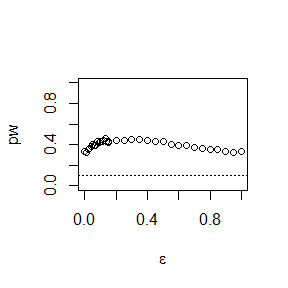

```r
#plot power vs epsilon
plot(epsilon, pw, type = "b",
     xlab = bquote(epsilon), ylim = c(0,1))
abline(h = 0.1, lty = 3)
```

# The homework 6

7.7

```r
#Use bootstrap to estimate the bias and standard error of θ
set.seed(0)   #生成种子
library(boot)  #加载程辑包
library(bootstrap)
lambda_hat <- eigen(cov(scor))$values #初始lambda值
the.hat <- lambda_hat[1] / sum(lambda_hat)
B <- 2000 # number of bootstrap samples
n <- nrow(scor) # number of rows (data size)
# 进行Bootstrap抽样
func <- function(dat, index){
  x <- dat[index,]
  lambda <- eigen(cov(x))$values
  theta <- lambda[1] / sum(lambda)
  return(theta)
}
bootstrap_result <- boot(
  data = cbind(scor$mec, scor$vec, scor$alg, scor$ana, scor$sta),
  statistic = func, R = B)
theta_b <- bootstrap_result$t
bias_boot <- mean(theta_b) - the.hat
# the estimated bias of theta_hat, using bootstrap
se_boot <- sqrt(var(theta_b))
# the estimated standard error (se) of theta_hat, using bootstrap
round(c(original=the.hat,estimate=mean(theta_b),bias_boot=bias_boot,se_boot=se_boot),5)
```

```
##  original  estimate bias_boot   se_boot
##   0.61912   0.62075   0.00163   0.04708
```

7.8

#Load the package and read in the data to calculate the data covariance matrix. Show the first five rows of data.

```r
#calculate the data covariance matrix
library(bootstrap) #for the score data
cov(scor)
```

```
##          mec       vec       alg       ana       sta
## mec 305.7680 127.22257 101.57941 106.27273 117.40491
## vec 127.2226 172.84222  85.15726  94.67294  99.01202
## alg 101.5794  85.15726 112.88597 112.11338 121.87056
## ana 106.2727  94.67294 112.11338 220.38036 155.53553
## sta 117.4049  99.01202 121.87056 155.53553 297.75536
```

```r
#show a part of data
scor[1:5,]
```

```
##   mec vec alg ana sta
## 1  77  82  67  67  81
## 2  63  78  80  70  81
## 3  75  73  71  66  81
## 4  55  72  63  70  68
## 5  63  63  65  70  63
```

A function that defines a covariance matrix

```r
#A function that defines a covariance matrix
mcov <- function(x,j) cov(x[j,])
```

We obtain the jackknife estimates of bias and standard error of $\hat{\theta}$

```r
#Computing data dimension
n<-lengths(scor)[1]
#Calculate the real covariance matrix
real.cov <- mcov(scor,1:n)
#Calculate the real theta value
the.hat<-eigen(real.cov)$values[1]/sum(eigen(real.cov)$values)
#Define variables to store values
the.jack <- numeric(n)
#Loop n times
for(i in 1:n){
  the.cov <- mcov(scor,(1:n)[-i])
  #Get matrix eigenvalues
  eig1<-eigen(the.cov)$values
  #Find the estimate of lambda
  the.jack[i]<-eig1[1]/sum(eig1)
}
#Calculation bias
bias1 <- (n-1)*(mean(the.jack)-the.hat)
#Calculating  standard deviation
se1 <- sqrt((n-1)*mean((the.jack-the.hat)^2))
round(c(original=the.hat,estimate=mean(the.jack),bias1=bias1,
        se1=se1),4)
```

```
##  original  estimate bias1.mec   se1.mec
##    0.6191    0.6191    0.0011    0.0496
```

$\textbf{Analysis}$:The estimated value of lambda is 0.619.The deviation is only 0.001, it can be seen that the Jacknife method works better. The standard deviation value is 0.05

7.9

```r
#Compute 95% percentile and BCa confidence intervals for θ
set.seed(0)
library(boot)
library(bootstrap)
lambda_hat <- eigen(cov(scor))$values
theta_hat <- lambda_hat[1] / sum(lambda_hat)
B <- 2000 # number of bootstrap samples
n <- nrow(scor) # number of rows (data size)
# Bootstrap
func <- function(dat, index){
  x <- dat[index,]
  lambda <- eigen(cov(x))$values
  theta <- lambda[1] / sum(lambda)
  return(theta)
}
#对数据进行B=2000次Bootstrap抽样
bootstrap_result <- boot(
  data = cbind(scor$mec, scor$vec, scor$alg, scor$ana, scor$sta),
  statistic = func, R = B)
ci<-boot.ci(bootstrap_result,type=c("perc","bca"))
ci.perc<-ci$percent[4:5]   #计算得到95%的percentile和BCa的置信区间
ci.bca<-ci$bca[4:5]
round(c(ci.perc,ci.bca),4)
```

[output not shown]

7.B

```r
#Calculate the skewness with the following function
sk <- function(x,j) {
  #computes the sample skewness coeff.
  xbar <- mean(x[j])
  m3 <- mean((x[j] - xbar)^3)
  m2 <- mean((x[j] - xbar)^2)
  return( m3 / m2^1.5 )
}
```

$\text{Normal distribution}$

We take a sample with a normal distribution of N(0,2), the sample size is 20, and each time we do bootstrap 1000 times, we cycle 1000 experiments. The coverage of the interval is calculated based on the experimental results.

```r
#Compare the coverage rates
me<-0
n<-20
m<-1000
set.seed(12345)
library(boot)
nor.norm<-nor.basic<-nor.perc<-matrix(NA,m,2)
for (i in 1:m) {
  data.nor<-rnorm(n,0,2)
  nor.ske<-boot(data.nor,statistic=sk,R=1000)
  nor<- boot.ci(nor.ske,type=c("norm","basic","perc"))
  nor.norm[i,]<-nor$norm[2:3];
  nor.basic[i,]<-nor$basic[4:5];
  nor.perc[i,]<-nor$percent[4:5];
}
#Calculate the coverage probability of a normal distribution
cat('norm =',mean(nor.norm[,1]<=me & nor.norm[,2]>=me),
    'basic =',mean(nor.basic[,1]<=me & nor.basic[,2]>=me),
    'perc =',mean(nor.perc[,1]<=me & nor.perc[,2]>=me))
#Calculate the probability of the left side of the normal distribution
cat('norm.left=',mean(nor.norm[,1]>=me ),
    'basic.left =',mean(nor.basic[,1]>=me ),
    'perc.left =',mean(nor.perc[,1]>=me))
#Calculate the right side probability of a normal distribution
cat('norm.right=',mean(nor.norm[,2]<=me ),
    'basic.right =',mean(nor.basic[,2]<=me ),
    'perc.right =',mean(nor.perc[,2]<=me))
```

[output not shown]

$\text{Chi-square distribution}$ Calculating true skewness using Monte Carlo method.

```r
pian.real<-mean(replicate(1000,expr = {
  x0<-rchisq(1000,5)
  mean((x0-5)^3)/10^1.5
}))
print(pian.real)
```

```
## [1] 1.269027
```

We take a sample with a normal distribution of $\chi^{2}(5)$, the sample size is 20, and each time we do bootstrap 1000 times, we cycle 1000 experiments. The coverage of the interval is calculated based on the experimental results.

```r
me<-pian.real
n<-20
m<-1000
set.seed(12345)
library(boot)
chi.norm<-chi.basic<-chi.perc<-matrix(NA,m,2)
for (i in 1:m) {
  data.chisq<-rchisq(n,5)
  chisq.ske<-boot(data.chisq,statistic=sk,R=1000)
  chi<- boot.ci(chisq.ske,type=c("norm","basic","perc"))
  chi.norm[i,]<-chi$norm[2:3];
  chi.basic[i,]<-chi$basic[4:5];
  chi.perc[i,]<-chi$percent[4:5];
}
#Calculate the coverage probability of the chi-square distribution
cat('norm =',mean(chi.norm[,1]<=me & chi.norm[,2]>=me),
    'basic =',mean(chi.basic[,1]<=me & chi.basic[,2]>=me),
    'perc =',mean(chi.perc[,1]<=me & chi.perc[,2]>=me))
#Calculate the probability of the left side of the chi-square distribution
cat('norm.left=',mean(chi.norm[,1]>=me ),
    'basic.left =',mean(chi.basic[,1]>=me ),
    'perc.left =',mean(chi.perc[,1]>=me))
#Calculate the right side probability of the chi-square distribution
cat('norm.right=',mean(chi.norm[,2]<=me ),
    'basic.right =',mean(chi.basic[,2]<=me ),
    'perc.right =',mean(chi.perc[,2]<=me))
```

[output not shown]

# The homework 7

##answer

8.2

```r
# Implement the bivariate Spearman rank correlation test for independence as a permutation test
#自行生成0到10的十个随机数
x<-runif(10,0,10)
y<-runif(10,0,10)
R <- 999 #重复次数
z <- c(x, y) #集中样本
N <- 1:20
reps <- numeric(R)
t0 <- cor.test(x, y)$statistic
for (i in 1:R) {
  n <- sample(N, size = 10, replace = FALSE)  #产生样本指标
  x1 <- z[n]
  y1 <- z[-n] #z中拿走x1后剩下的给y1
  reps[i] <- cor.test(x1, y1)$statistic #相关系数检验
}
p <- mean(abs(c(t0, reps)) >= abs(t0))
p_value<-cor.test(x,y)$p.value
round(c(p=p,p_value=p_value),3)
```

[output not shown]

##Exercise2

```r
library(boot)
library(RANN)
library(energy)
library(Ball)
#NN检验函数
Tn <- function(z, ix, sizes,k) {
  n1 <- sizes[1]; n2 <- sizes[2]; n <- n1 + n2
  if(is.vector(z)) z <- data.frame(z)
  z <- z[ix, ]
  NN <- nn2(data=z, k=k+1)
  block1 <- NN$nn.idx[1:n1,-1]
  block2 <- NN$nn.idx[(n1+1):n,-1]
  i1 <- sum(block1 <= n1); i2 <- sum(block2 > n1)
  (i1 + i2) / (k * n)
}
eqdist.nn <- function(z,sizes,k){
  boot.obj <- boot(data=z,statistic=Tn,R=R,sim = "permutation", sizes = sizes,k=k)
  ts <- c(boot.obj$t0,boot.obj$t)
  p.value <- mean(ts>=ts[1])
  list(statistic=ts[1],p.value=p.value)
}
```

#1.Unequal variances and equal expectations

```r
m <- 1e3
k<-3
set.seed(12345)
n1 <- n2 <- 25
R<-999
n <- n1+n2
N = c(n1,n2)
p_values <- matrix(NA,m,3)
for(i in 1:m){
  x <- matrix(rnorm(n1*2,0,1),ncol=2)  #生成均值为0，方差为1的随机阵
  y <- matrix(rnorm(n1*2,0,2),ncol=2)  #生成均值为0，方差为2的随机阵
  z <- rbind(x,y)
  p_values[i,1] <- eqdist.nn(z,N,k)$p.value
  p_values[i,2] <- eqdist.etest(z,sizes=N,R=R)$p.value
  p_values[i,3] <- bd.test(x=x,y=y,num.permutations=R,seed=i*12345)$p.value
}
alpha <- 0.1
pow <- colMeans(p_values<alpha)
pow
```

[output not shown]

#2.Unequal variances and unequal expectations

```r
m <- 1e3
k<-3
set.seed(12345)
n1 <- n2 <- 25
R<-999
n <- n1+n2
N = c(n1,n2)
p_values <- matrix(NA,m,3)
for(i in 1:m){
  x <- matrix(rnorm(n1*2,0,1),ncol=2)  #生成均值为0，方差为1的随机阵
  y <- matrix(rnorm(n1*2,1,2),ncol=2)  #生成均值为1，方差为2的随机阵
  z <- rbind(x,y)
  p_values[i,1] <- eqdist.nn(z,N,k)$p.value
  p_values[i,2] <- eqdist.etest(z,sizes=N,R=R)$p.value
  p_values[i,3] <- bd.test(x=x,y=y,num.permutations=R,seed=i*12345)$p.value
}
alpha <- 0.1
pow <- colMeans(p_values<alpha)
pow
```

[output not shown]

#3.Non-normal distributions: t distribution with 1 df (heavy-taileddistribution), bimodel distribution (mixture of two normal distributions)

```r
m <- 1e3
k<-3
set.seed(12345)
n1 <- n2 <- 25
R<-999
n <- n1+n2
N = c(n1,n2)
p_values <- matrix(NA,m,3)
for(i in 1:m){
  #t distribution with 1 df
  x <- matrix(rt(n1*2,1),ncol=2)  #生成自由度为1的t分布的随机阵
  y <- matrix(rt(n1*2,1),ncol=2)  #生成自由度为1的t分布的随机阵
  z <- rbind(x,y)
  p_values[i,1] <- eqdist.nn(z,N,k)$p.value
  p_values[i,2] <- eqdist.etest(z,sizes=N,R=R)$p.value
  p_values[i,3] <- bd.test(x=x,y=y,num.permutations=R,seed=i*12345)$p.value
}
alpha <- 0.05
pow <- colMeans(p_values<alpha)
pow
```

[output not shown]

```r
m <- 1e3
k<-3
set.seed(12345)
n1 <- n2 <- 25
R<-999
n <- n1+n2
N = c(n1,n2)
p_values <- matrix(NA,m,3)
for(i in 1:m){
  #bimodel distribution
  a<-rnorm(n1*2+n2*2);b<-rnorm(n1*2+n2*2,1,2);
  M1<-0.3*a+0.7*b
  x <- matrix(M1,nrow=n1,ncol=2)  #mixture of two normal distributions
  y <- matrix(M1,nrow=n2,ncol=2)  #mixture of two normal distributions
  z <- rbind(x,y)
  p_values[i,1] <- eqdist.nn(z,N,k)$p.value
  p_values[i,2] <- eqdist.etest(z,sizes=N,R=R)$p.value
  p_values[i,3] <- bd.test(x=x,y=y,num.permutations=R,seed=i*12345)$p.value
}
alpha <- 0.05
pow <- colMeans(p_values<alpha)
pow
```

[output not shown]

#4.Unbalanced samples (say, 1 case versus 10 controls)

```r
m <- 1e3
k<-3
set.seed(12345)
n1 <- 5;n2 <- 50
R<-999
n <- n1+n2
N = c(n1,n2)
p_values <- matrix(NA,m,3)
for(i in 1:m){
  a<-rnorm(20);b<-rnorm(200,1,2);
  #分别抽取10个和100个样本
  m1 <- sample(a, size = 10, replace = FALSE)
  m2 <- sample(b, size = 100, replace = FALSE)
  #生成随机阵
  x <- matrix(m1,ncol=2)
  y <- matrix(m2,ncol=2)
  z <- rbind(x,y)
  p_values[i,1] <- eqdist.nn(z,N,k)$p.value
  p_values[i,2] <- eqdist.etest(z,sizes=N,R=R)$p.value
  p_values[i,3] <- bd.test(x=x,y=y,num.permutations=R,seed=i*12345)$p.value
}
alpha <- 0.1
pow <- colMeans(p_values<alpha)
pow
```

```
## [1] 0.197 0.436 0.870
```

三次检验中Ball比较显著

#5.Note: The parameters should be chosen such that the powers are distinguishable (say, range from 0.3 to 0.8)

The answer is the same as the forth question,likewise the powers are distinguishable which from 0.1 to 0.8,and the Ball method is more powerful.